# Phân tích Thành phần chính cho Bộ dữ liệu Boston Housing

## 4.3. Nhóm theo MEDV_cat

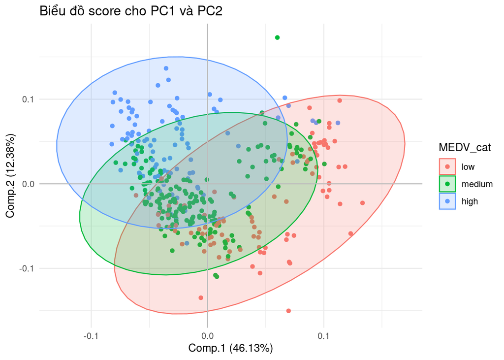

```r
library(ggfortify)
autoplot(pca, loadings = FALSE, frame = TRUE, frame.type = "norm",
         colour = "MEDV_cat", data = data_clean,
         main = "Biểu đồ score cho PC1 và PC2") +
  geom_vline(xintercept = 0, color = "gray") +
  geom_hline(yintercept = 0, color = "gray") +
  theme_minimal()
```

**Nhận xét:**

- Từ đồ thị phân tán, chúng ta có thể thấy rằng phần lớn các khu vực có giá nhà cao (high) có giá trị của thành phần chính thứ nhất thấp hơn so với phần lớn các khu vực có giá nhà thấp (low). Do đó, thành phần chính thứ nhất có khả năng tách tương đối các mẫu khu vực giá nhà cao với mẫu khu vực giá nhà thấp.
- Thành phần chính thứ hai khó có thể tự tách biệt các mẫu của ba khu vực với nhau. Tuy nhiên, khi kết hợp với thành phần chính thứ nhất sẽ giúp tăng khả năng tách biệt các nhóm khu vực, cụ thể:
  - Nhóm khu vực giá nhà cao (high): Tập trung nhiều ở góc trái trên (PC1 < 0, PC2 > 0).
  - Nhóm khu vực giá nhà thấp (low): Tập trung nhiều ở phía phải (PC1 > 0), càng về phía bên phải và xuống dướ (PC1 > 0, PC2 <
    0. thì càng tách biệt rõ với nhóm khu vực giá nhà vừa phải (medium).
- Các khu vực có giá nhà vừa phải (medium) chồng lấn lên cả hai nhóm còn lại dẫn tới khó phân biệt hoàn toàn dù có kết hợp cả hai thành phần chính đầu tiên.
- Ngoài ra, ta thấy các nhóm khu vực có giá nhà từ thấp đến cao có phân bố các mẫu chuyển dịch từ góc phải dưới lên dần góc trái trên. Nghĩa là, các khu vực có giá nhà càng cao thì càng tỉ lệ thuận với RM, ZN và tỉ lệ nghịch với LSTAT, TAX, CRIM, NOX, INDUS, RAD, AGE. Tức là các khu vực có giá nhà càng cao thì số phòng càng nhiều, tỷ lệ quy hoạch đất ở theo lô lớn càng cao và tỷ lệ dân cư tầng lớp thấp, thuế, tệ nạn, ô nhiễm… càng thấp. Ngược lại, các khu vực có giá nhà càng thấp thì tỷ lệ dân cư tầng lớp thấp, thuế, tệ nạn, ô nhiễm… càng cao và số phòng, tỷ lệ đất theo lô lớn càng giảm.

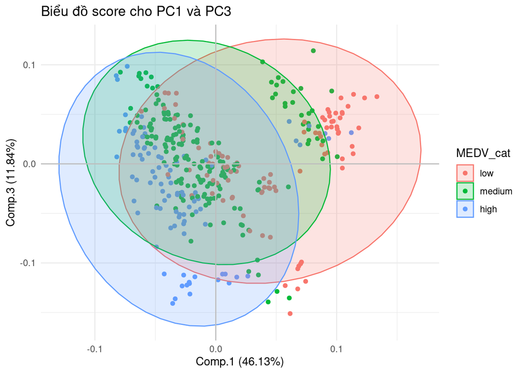

```r
autoplot(pca, x = 1, y = 3, loadings = FALSE, frame = TRUE, frame.type = "norm",
         colour = "MEDV_cat", data = data_clean,
         main = "Biểu đồ score cho PC1 và PC3") +
  geom_vline(xintercept = 0, color = "gray") +
  geom_hline(yintercept = 0, color = "gray") +
  theme_minimal()
```

**Nhận xét:**

Từ đồ thị phân tán hiển thị thành phần chính đầu tiên trên trục hoành và thành phần chính thứ ba trên trục tung, ta có thể thấy khả năng tách biệt các nhóm khu vực theo giá nhà còn tệ hơn cả khi kết hợp thành phần chính thứ nhất và thành phần chính thứ hai (thậm chí là không thể phân tách được giá của khu vực nào do chồng lấn quá nhiều). Do đó, thành phần chính thứ ba không có khả năng tách các mẫu khu vực theo giá nhà.

## 4.4. Nhóm theo CHAS

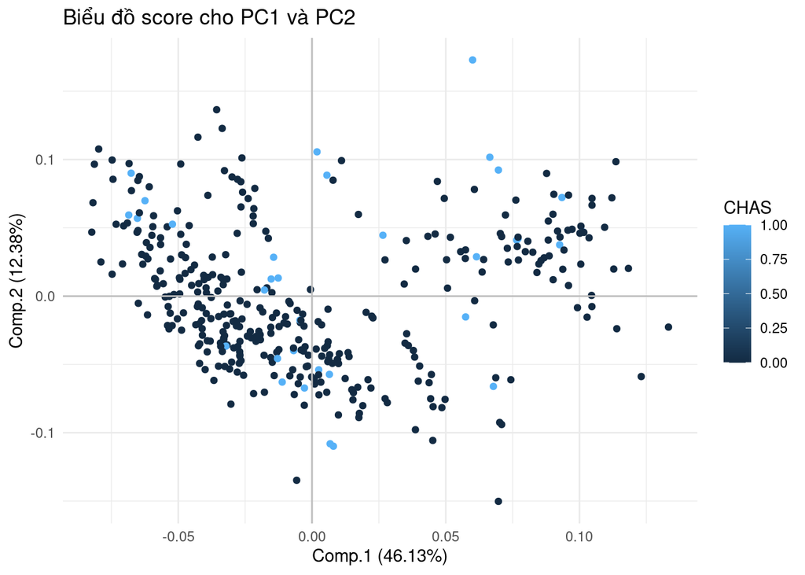

```r
autoplot(pca, loadings = FALSE,
         colour = "CHAS", data = data_clean,
         main = "Biểu đồ score cho PC1 và PC2") +
  geom_vline(xintercept = 0, color = "gray") +
  geom_hline(yintercept = 0, color = "gray") +
  theme_minimal()
```

**Nhận xét:**

Từ đồ thị phân tán, ta có thể thấy khả năng tách biệt các nhóm khu vực theo biến CHAS - có giáp sông Charles hay không - rất tệ khi cả hai lớp 0 và 1 đều phân bố ngẫu nhiên quan hai trục là hai thành phần chính đầu tiên. Do đó, hai thành phần chính đầu tiên không có khả năng tách các mẫu khu vực theo việc giáp sông Charles.

# 5. Thử các phương pháp khác

## 5.1. Phân tích nhân tố

```r
fa = factanal(data_scaled, factors = 5, rotation = "none")
fa
```

```
##
## Call:
## factanal(x = data_scaled, factors = 5, rotation = "none")
##
## Uniquenesses:
##    CRIM      ZN   INDUS     NOX      RM     AGE     DIS     RAD     TAX PTRATIO
##   0.195   0.578   0.268   0.185   0.412   0.283   0.236   0.015   0.094   0.121
##       B   LSTAT
##   0.812   0.005
##
## Loadings:
##         Factor1 Factor2 Factor3 Factor4 Factor5
## CRIM     0.566   0.692
## ZN      -0.356                  -0.530
## INDUS    0.590   0.338  -0.237   0.373  -0.273
## NOX      0.582   0.359  -0.529   0.245
## RM      -0.613   0.205  -0.236           0.333
## AGE      0.572   0.112  -0.423   0.342   0.286
## DIS     -0.425  -0.264   0.544  -0.455  -0.105
## RAD      0.476   0.867
## TAX      0.535   0.774                  -0.124
## PTRATIO  0.320   0.278   0.659   0.514
## B       -0.182  -0.218   0.245           0.217
## LSTAT    0.980  -0.187
##
##                Factor1 Factor2 Factor3 Factor4 Factor5
## SS loadings      3.627   2.366   1.373   1.080   0.351
## Proportion Var   0.302   0.197   0.114   0.090   0.029
## Cumulative Var   0.302   0.499   0.614   0.704   0.733
##
## Test of the hypothesis that 5 factors are sufficient.
## The chi square statistic is 32.01 on 16 degrees of freedom.
## The p-value is 0.00998
```

```r
fa_max = factanal(data_scaled, factors = 5, rotation = "varimax")
fa_max
```

```
##
## Call:
## factanal(x = data_scaled, factors = 5, rotation = "varimax")
##
## Uniquenesses:
##    CRIM      ZN   INDUS     NOX      RM     AGE     DIS     RAD     TAX PTRATIO
##   0.195   0.578   0.268   0.185   0.412   0.283   0.236   0.015   0.094   0.121
##       B   LSTAT
##   0.812   0.005
##
## Loadings:
##         Factor1 Factor2 Factor3 Factor4 Factor5
## CRIM     0.825   0.287   0.157
## ZN              -0.496  -0.140  -0.365  -0.142
## INDUS    0.382   0.515   0.289   0.208   0.441
## NOX      0.432   0.687   0.186           0.339
## RM                      -0.714  -0.211  -0.179
## AGE      0.211   0.794   0.198
## DIS     -0.236  -0.814                  -0.210
## RAD      0.961   0.168           0.156
## TAX      0.853   0.256   0.123   0.188   0.252
## PTRATIO  0.247           0.188   0.879
## B       -0.230  -0.167                  -0.307
## LSTAT    0.220   0.384   0.890
##
##                Factor1 Factor2 Factor3 Factor4 Factor5
## SS loadings      2.930   2.629   1.559   1.081   0.597
## Proportion Var   0.244   0.219   0.130   0.090   0.050
## Cumulative Var   0.244   0.463   0.593   0.683   0.733
##
## Test of the hypothesis that 5 factors are sufficient.
## The chi square statistic is 32.01 on 16 degrees of freedom.
## The p-value is 0.00998
```

**Nhận xét:**

1. Về kiểm định hợp lý: Trong kiểm định tính hợp lý của mô hình nhân tố với giả thuyết:
- H0: Mô hình 5 nhân tố là phù hợp
- H1: Mô hình 5 nhân tố là không phù hợp

Với mức ý nghĩa alpha = 0.001 (0.1%), thì do p-value = 0.00998 > 0.001 nên ta chấp nhận H0: Mô hình 5 nhân tố là phù hợp. Vậy mô hình 5 nhân tố là phù hợp với mức ý nghĩa 0.001.

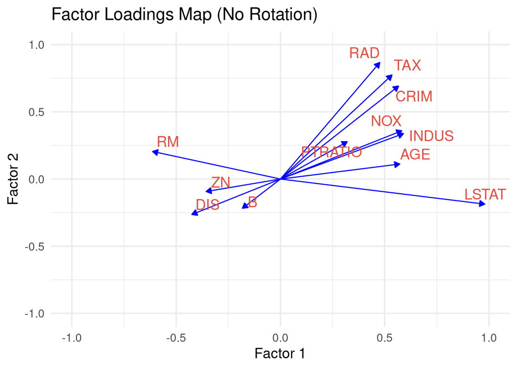

```r
# Lấy ma trận loadings từ mô hình xoay Varimax
loadings_matrix <- fa$loadings

factor_loadings <- data.frame(
  Indicator = c("CRIM", "ZN", "INDUS", "NOX", "RM", "AGE", "DIS", "RAD", "TAX", "PTRATIO", "B", "LSTAT"),
  F1 = loadings_matrix[, 1],
  F2 = loadings_matrix[, 2]
)

# Vẽ biểu đồ vector các loadings
ggplot(factor_loadings, aes(x = F1, y = F2, label = Indicator)) +
  geom_segment(aes(x = 0, y = 0, xend = F1, yend = F2),
               color = "blue",
               arrow = arrow(length = unit(0.2, "cm"), type = "closed")) +
  geom_text_repel(color = "#E74C3C", size = 5) +
  xlim(-1, 1) + ylim(-1, 1) +
  theme_minimal(base_size = 14) +
  ggtitle("Factor Loadings Map (No Rotation)") +
  xlab("Factor 1") + ylab("Factor 2")
```

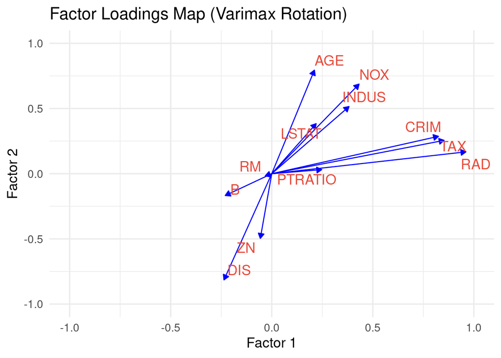

```r
# Lấy ma trận loadings từ mô hình xoay Varimax
loadings_matrix <- fa_max$loadings

factor_loadings <- data.frame(
  Indicator = c("CRIM", "ZN", "INDUS", "NOX", "RM", "AGE", "DIS", "RAD", "TAX", "PTRATIO", "B", "LSTAT"),
  F1 = loadings_matrix[, 1],
  F2 = loadings_matrix[, 2]
)

# Vẽ biểu đồ vector các loadings
ggplot(factor_loadings, aes(x = F1, y = F2, label = Indicator)) +
  geom_segment(aes(x = 0, y = 0, xend = F1, yend = F2),
               color = "blue",
               arrow = arrow(length = unit(0.2, "cm"), type = "closed")) +
  geom_text_repel(color = "#E74C3C", size = 5) +
  xlim(-1, 1) + ylim(-1, 1) +
  theme_minimal(base_size = 14) +
  ggtitle("Factor Loadings Map (Varimax Rotation)") +
  xlab("Factor 1") + ylab("Factor 2")
```

Từ hình vẽ ta thấy phép quay varimax thực sự giúp tăng khả năng giải thích và đơn giản hóa việc hiểu và đặt tên cho các nhân tố tiềm ẩn.

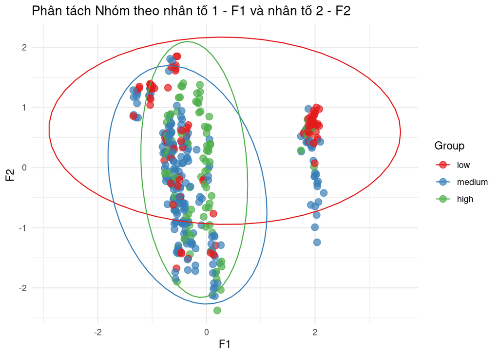

```r
# Chạy lại phân tích nhân tố nhưng thêm scores
fa_clus = factanal(data_scaled, factors = 5, rotation = "varimax", scores = "regression")

# Trích xuất factor scores
scores <- as.data.frame(fa_clus$scores)
colnames(scores) <- c("F1", "F2", "F3", "F4", "F5")

scores$Group = data_clean$MEDV_cat

# Vẽ đồ thị phân tán theo nhân tố 1 và 2
ggplot(scores, aes(x = F1, y = F2, color = Group)) +
  geom_point(alpha = 0.7, size = 3) +
  labs(
    title = "Phân tách Nhóm theo nhân tố 1 - F1 và nhân tố 2 - F2",
    x = "F1",
    y = "F2 "
  ) +
  theme_minimal() +
  scale_color_brewer(palette = "Set1") +
  stat_ellipse(level = 0.95)  # Vẽ ellipse bao quanh nhóm
```

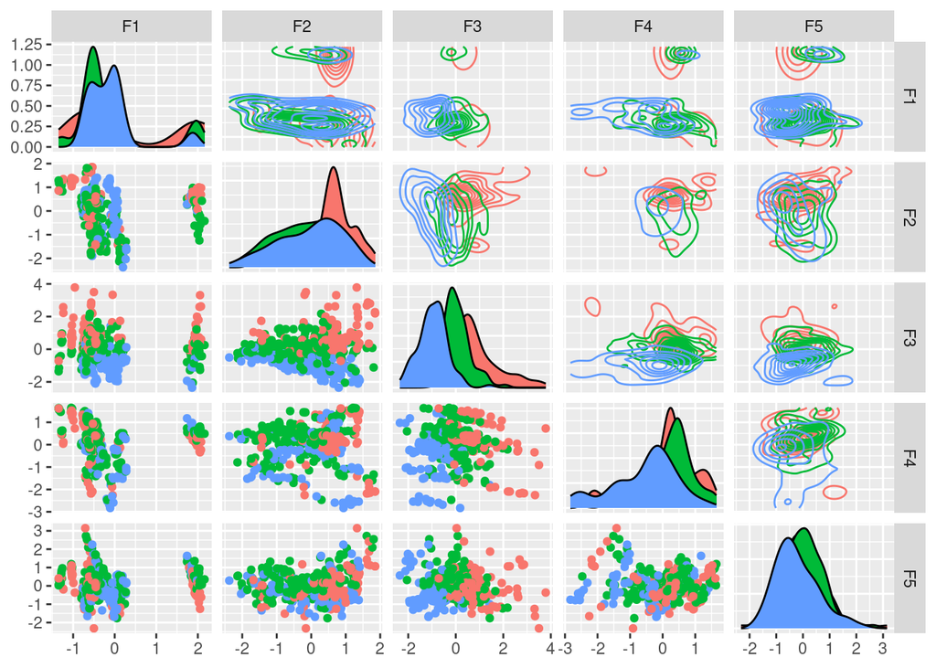

```r
ggpairs(
  data = scores,
  columns = 1:5,  # Chọn nhân tố F1-F3
  mapping = aes(color = Group),
  upper = list(continuous = "density"),
  lower = list(continuous = "points")
)
```

**Kết luận:**

- Với việc giữ lại tới 5 nhân tố nhưng tổng tỷ lệ phương sai giải thích được của mô hình nhân tố chỉ là khoảng 73.3%, cao hơn chỉ khoảng 3% so với việc giữ lại 3 thành phần chính đầu tiên khi phân tích thành phần chính (70.35%).
- Ngoài ra, khi trực quan hóa để quan sát khả năng phân tách các nhóm giá nhà dựa theo các nhân tố thì ta thấy khả năng phân tách của các nhân tố đều kém hơn so với các thành phần chính.

==> Như vậy, để phân tách các nhóm giá nhà tốt hơn, đồng thời hiệu quả lưu giữ phương sai suy rộng cao hơn thì ta nên chọn phân tích thành phần chính thay vì phân tích nhân tố.

# 6. Xây dựng mô hình với các Thành phần chính

```r
data_housing_clean$MEDV = data_clean$MEDV

model_raw = lm(MEDV ~ CRIM + ZN + INDUS + NOX + RM + AGE + DIS + RAD + TAX + PTRATIO + B + LSTAT, data = data_housing_clean)
summary(model_raw)
```

```
##
## Call:
## lm(formula = MEDV ~ CRIM + ZN + INDUS + NOX + RM + AGE + DIS +
##     RAD + TAX + PTRATIO + B + LSTAT, data = data_housing_clean)
##
## Residuals:
##     Min      1Q  Median      3Q     Max
## -17.802  -2.588  -0.487   1.668  27.314
##
## Coefficients:
##               Estimate Std. Error t value Pr(>|t|)
## (Intercept)  37.779341   8.561521   4.413 1.35e-05 ***
## CRIM         -0.145819   0.179676  -0.812 0.417572
## ZN            0.007986   0.026495   0.301 0.763255
## INDUS         0.060896   0.064639   0.942 0.346771
## NOX         -15.818551   4.565649  -3.465 0.000594 ***
## RM            5.157491   0.536264   9.617  < 2e-16 ***
## AGE           0.002982   0.014767   0.202 0.840084
## DIS          -1.236227   0.233565  -5.293 2.09e-07 ***
## RAD           0.357772   0.098344   3.638 0.000314 ***
## TAX          -0.014286   0.004754  -3.005 0.002841 **
## PTRATIO      -1.025243   0.153661  -6.672 9.41e-11 ***
## B            -0.017133   0.016714  -1.025 0.306008
## LSTAT        -0.525131   0.067643  -7.763 8.47e-14 ***
## ---
## Signif. codes:  0 '***' 0.001 '**' 0.01 '*' 0.05 '.' 0.1 ' ' 1
##
## Residual standard error: 4.71 on 364 degrees of freedom
## Multiple R-squared:  0.7091, Adjusted R-squared:  0.6995
## F-statistic: 73.95 on 12 and 364 DF,  p-value: < 2.2e-16
```

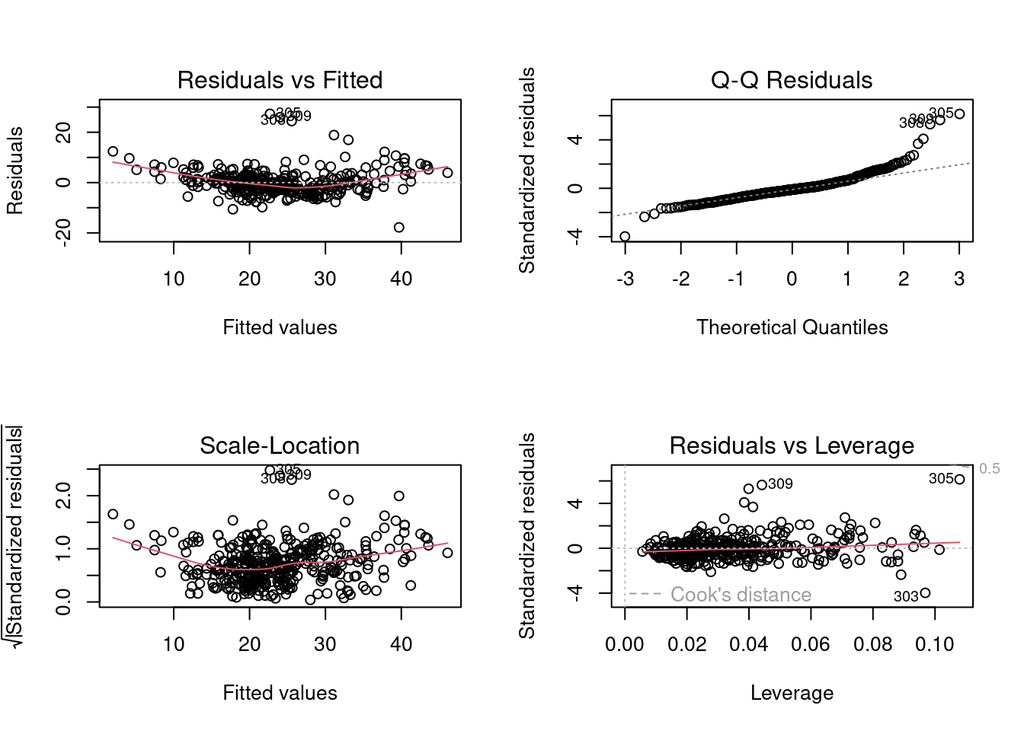

```r
par(mfrow = c(2, 2))
plot(model_raw)
```

```r
vif(model_raw)
```

```
##     CRIM       ZN    INDUS      NOX       RM      AGE      DIS      RAD
## 4.907609 1.651042 2.864629 4.005081 2.155168 2.629374 2.982030 9.708872
##      TAX  PTRATIO        B    LSTAT
## 8.824253 1.726683 1.201084 2.876940
```

```r
pca_data = as.data.frame(pca$scores)
pca_data$MEDV = data_clean$MEDV

model_pca = lm(MEDV ~ Comp.1 + Comp.2 + Comp.3 + Comp.4, data = pca_data)
summary(model_pca)
```

```
##
## Call:
## lm(formula = MEDV ~ Comp.1 + Comp.2 + Comp.3 + Comp.4, data = pca_data)
##
## Residuals:
##      Min       1Q   Median       3Q      Max
## -18.4795  -2.4402  -0.4332   1.7106  30.8848
##
## Coefficients:
##             Estimate Std. Error t value Pr(>|t|)
## (Intercept)  23.7011     0.2536  93.460  < 2e-16 ***
## Comp.1       -1.5419     0.1079 -14.285  < 2e-16 ***
## Comp.2        4.1874     0.2084  20.097  < 2e-16 ***
## Comp.3       -2.1617     0.2130 -10.149  < 2e-16 ***
## Comp.4       -2.0034     0.2548  -7.863 4.11e-14 ***
## ---
## Signif. codes:  0 '***' 0.001 '**' 0.01 '*' 0.05 '.' 0.1 ' ' 1
##
## Residual standard error: 4.924 on 372 degrees of freedom
## Multiple R-squared:  0.675,  Adjusted R-squared:  0.6716
## F-statistic: 193.2 on 4 and 372 DF,  p-value: < 2.2e-16
```

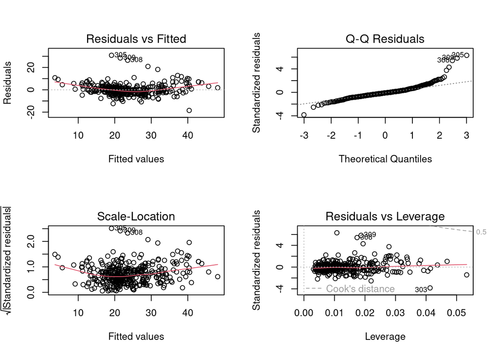

```r
par(mfrow = c(2, 2))
plot(model_pca)
```

```r
vif(model_pca)
```

```
## Comp.1 Comp.2 Comp.3 Comp.4
##      1      1      1      1
```

**Nhận xét:**

> Trong phần này, mục tiêu chính là đánh giá **hiệu quả mà PCA mang lại** khi được áp dụng vào mô hình Hồi quy Tuyến tính. Do đó, ta **không đi sâu vào phân tích chi tiết kết quả của từng mô hình riêng lẻ**, mà thay vào đó tập trung vào việc so sánh tổng thể giữa mô hình gốc và mô hình sau khi áp dụng PCA. Việc so sánh này nhằm chỉ ra:

> - **Mức độ tương đồng về kết quả dự đoán** giữa hai mô hình

> - **Những lợi ích** mà PCA mang lại

> - Và **cái giá phải trả** khi sử dụng PCA

> Mục tiêu cuối cùng là rút ra nhận định về **tính hiệu quả và tính đánh đổi** của PCA trong bối cảnh áp dụng cho Hồi quy Tuyến tính.

Trong phần này, ta tiến hành so sánh hai mô hình hồi quy tuyến tính:

#### 1. Độ phù hợp mô hình

| Tiêu chí | Mô hình Biến gốc | Mô hình PCA |
| --- | --- | --- |
| Residual Std. Error (RSE) | 4.71 | 4.924 |
| R-squared | 0.7091 | 0.675 |
| Adjusted R-squared | 0.6995 | 0.6716 |
| F-statistic | 73.95 (df = 12, 364) | 193.2 (df = 4, 372) |
| VIF | RAD (9.708872), TAX (8.824253), CRIM (4.907609) | Tất cả bằng 1 |

- Mô hình biến gốc có R-squared và Adjusted R-squared cao hơn, cho thấy khả năng giải thích phương sai trong `MEDV` tốt hơn.
- Mô hình PCA có RSE cao hơn một chút (4.924 so với 4.71), cho thấy sai số dự đoán trung bình lớn hơn.
- Tuy nhiên, F-statistic của mô hình PCA rất lớn (193.2) và vẫn có ý nghĩa thống kê cao, cho thấy các thành phần chính vẫn là những biến dự báo mạnh.
- VIF của các biến RAD, TAX rất cao và CRIM khá cao cho thấy mô hình biến gốc bị đa cộng tuyến. Trong khi mô hình PCA hoàn toàn không bị vấn đề này.

#### 2. Ý nghĩa các biến

- **Mô hình biến gốc:** Một số biến có ý nghĩa thống kê cao (`RM`, `LSTAT`, `PTRATIO`, `DIS`, `NOX`…), nhưng cũng có nhiều biến không có ý nghĩa rõ rệt (`CRIM`, `ZN`, `AGE`, `B`…).
- **Mô hình PCA:** Cả 4 thành phần chính đều có ý nghĩa thống kê rất cao (p < 0.001). Tuy nhiên, do đây là các biến tổng hợp, **việc giải thích cụ thể ảnh hưởng trực tiếp của từng biến ban đầu sẽ khó khăn hơn.**

#### 3. Sự đánh đổi

[output not shown]

#### 4. Kết luận

Tùy theo mục tiêu sử dụng, ta sẽ chọn mô hình phù hợp:

- Nếu mục tiêu là **dự báo chính xác và giải thích rõ các yếu tố ảnh hưởng**, mô hình biến gốc là lựa chọn phù hợp hơn tuy nhiên cần phải kết hợp các phương pháp khác để khắc phục vấn đề đa cộng tuyến.
- Nếu mục tiêu là **giảm chiều dữ liệu, tăng tính ổn định và chống đa cộng tuyến**, mô hình PCA là lựa chọn hợp lý, chấp nhận đánh đổi một phần độ chính xác.

Ngoài ra, nhìn vào 4 biểu đồ chẩn đoán từ 2 mô hình hồi quy tuyến tính ta thấy trong biểu đồ Residuals vs Fitted đường cong đỏ nhếch lên ở 2 đầu cho thấy mối quan hệ phi tuyến giữa biến độc lập và biến phụ thuộc. Vì vậy, với bộ dữ liệu này có thể chọn mô hình khác có khả năng giải thích được quan hệ phi tuyến sẽ phù hợp hơn.

# 7. Phương pháp có thể tốt hơn

Ta có các phương pháp hiện đại hơn tùy thuộc vào loại dữ liệu:

- Dữ liệu phi tuyến: UMAP, t-SNE, Autoencoders
- Dữ liệu lớn: UMAP, Sparse PCA
- Trực quan hóa: t-SNE

## 8. Kết luận

Kết luận: **PCA là phương pháp phù hợp để giảm chiều dữ liệu và hỗ trợ chẩn đoán giá nhà hiệu quả với bộ dữ liệu Boston Housing này**.